# Assignment for Reproducable Research

Elvis Zhang

Thursday, July 17, 2014

## Loading and preprocessing the data

```r
data<-read.csv("activity.csv")
cleaneddata<-na.omit(data)
```

## What is mean total number of steps taken per day?

For this part of the assignment, i ignore the missing values in the dataset.

1.Make a histogram of the total number of steps taken each day.

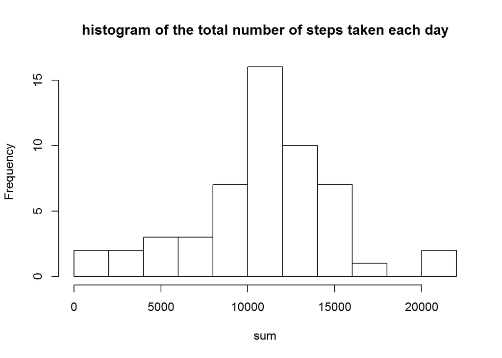

```r
sum<-tapply(cleaneddata$steps,cleaneddata$date,sum)
hist(sum,main="histogram of the total number of steps taken each day",breaks=10)
```

2.Calculate and report the mean and median total number of steps taken per day.

```r
mean(sum,na.rm=TRUE)
```

```
## [1] 10766
```

```r
median(sum,na.rm=TRUE)
```

```
## [1] 10765
```

## What is the average daily activity pattern?

1.Make a time series plot (i.e. type = “l”) of the 5-minute interval (x-axis) and the average number of steps taken, averaged across all days (y-axis)

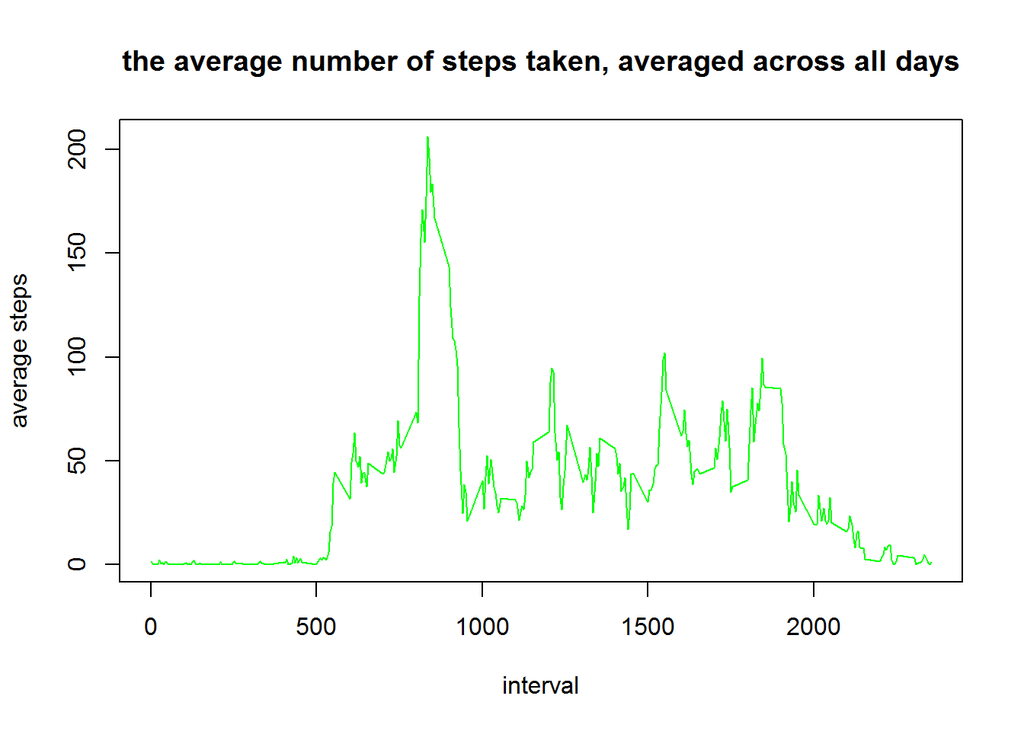

```r
avgstep<-tapply(cleaneddata$steps,cleaneddata$interval,mean)
plot(as.character(head(cleaneddata$interval,288)),as.numeric(avgstep),type="l",col="green",xlab="interval",ylab="average steps",main="the average number of steps taken, averaged across all days")
```

2.Which 5-minute interval, on average across all the days in the dataset, contains the maximum number of steps?

```r
avgstep<-data.frame(interval=head(cleaneddata$interval,288),avgstep=as.numeric(avgstep))
avgstep[avgstep==max(avgstep),1]
```

[output not shown]

## Imputing missing values

Note that there are a number of days/intervals where there are missing values (coded as NA). The presence of missing days may introduce bias into some calculations or summaries of the data.

1.Calculate and report the total number of missing values in the dataset (i.e. the total number of rows with NAs)

```r
nrow(data)-nrow(cleaneddata)
```

```
## [1] 2304
```

2.Devise a strategy for filling in all of the missing values in the dataset. The strategy does not need to be sophisticated. For example, you could use the mean/median for that day, or the mean for that 5-minute interval, etc.

I decide to replace the unaviable data with the mean for that 5-minute interval.

```r
replacement<-function(INTV=-1){n<-which(avgstep$"interval"==INTV)
  avgstep[n,"avgstep"]
}
```

3.Create a new dataset that is equal to the original dataset but with the missing data filled in.

```r
for(i in 1:nrow(data))
{
  if(is.na(data[i,"steps"]))
  {
    data[i,"steps"]<-replacement(data[i,"interval"])
  }
}
```

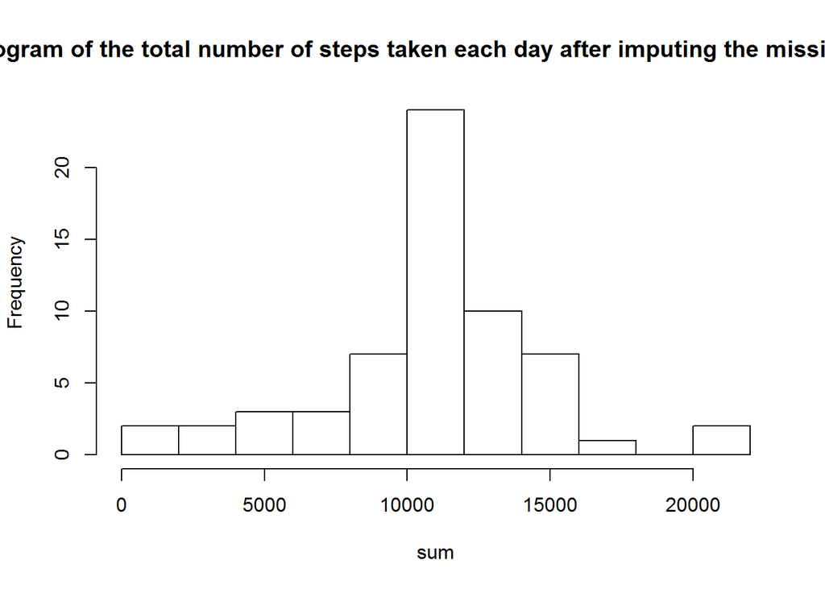

```r
sum<-tapply(data$steps,data$date,sum)
hist(sum,main="histogram of the total number of steps taken each day after imputing the missing value",breaks=10)
```

## Are there differences in activity patterns between weekdays and weekends?

1.Create a new factor variable in the dataset with two levels - “weekday” and “weekend” indicating whether a given date is a weekday or weekend day.

```r
day<-weekdays(as.Date(as.vector(data$date)))
weekend<-c("Saturday","Sunday")
data$weekend<- (day %in% weekend )
data$weekend<-as.factor(data$weekend)
levels(data$weekend)<-c("Weekday","Weekend")
```

2.Make a panel plot containing a time series plot (i.e. type = “l”) of the 5-minute interval (x-axis) and the average number of steps taken, averaged across all weekday days or weekend days (y-axis).

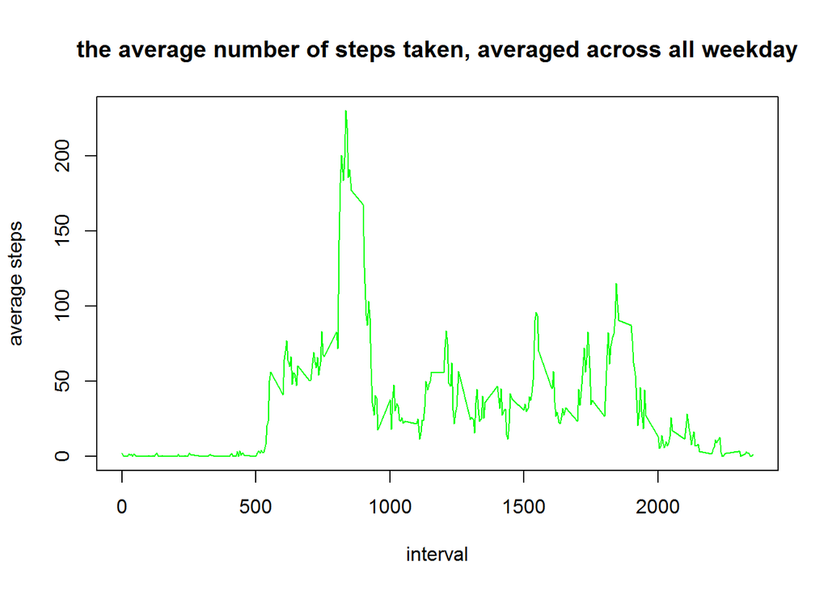

```r
data<-split(data,data$weekend)
weekday<-data$Weekday
weekend<-data$Weekend
avgstepofweekday<-tapply(weekday$steps,weekday$interval,mean)
avgstepofweekend<-tapply(weekend$steps,weekend$interval,mean)
plot(as.character(head(cleaneddata$interval,288)),as.numeric(avgstepofweekday),type="l",col="green",xlab="interval",ylab="average steps",main="the average number of steps taken, averaged across all weekday")
```

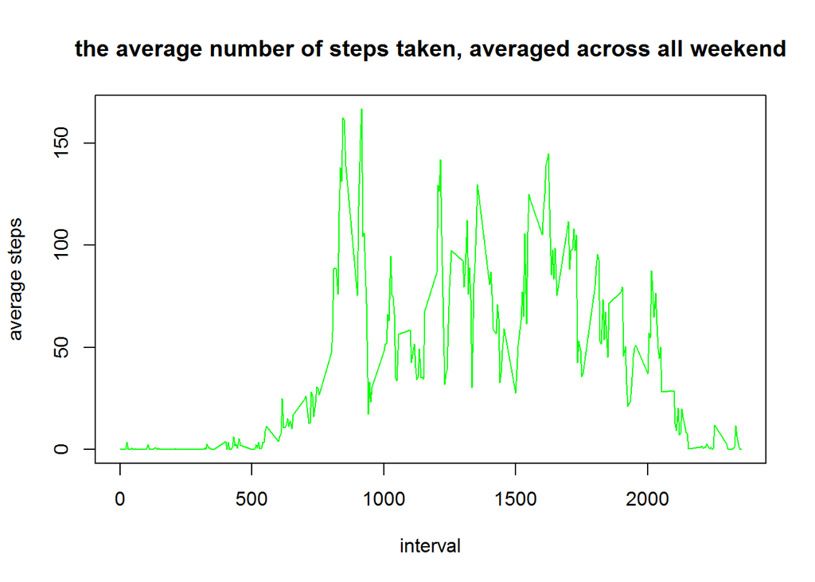

```r
plot(as.character(head(cleaneddata$interval,288)),as.numeric(avgstepofweekend),type="l",col="green",xlab="interval",ylab="average steps",main="the average number of steps taken, averaged across all weekend")
```